# R & Python in RStudio (test)

*by [Tatiana Kurilo](https://github.com/TianaQ)*

## Udacity Bertelsmann Data Science Challenge Course

### Lesson 2: Practice Problems

**Kathleen counts the number of petals on all the flowers in her garden.**

```
## Kathleen's petal counts:
```

```
## [15, 16, 15, 17, 14, 14, 14, 10, 15, 25, 16, 21, 16, 16, 13, 15, 15, 19, 22, 15, 17, 22, 15, 22, 14, 15, 16, 15, 24, 16]
```

**Create a histogram and describe the distribution of flower petals on Kathleen’s flowers. Use a bin size of 2.**

Let’s build the first histogram in Python.

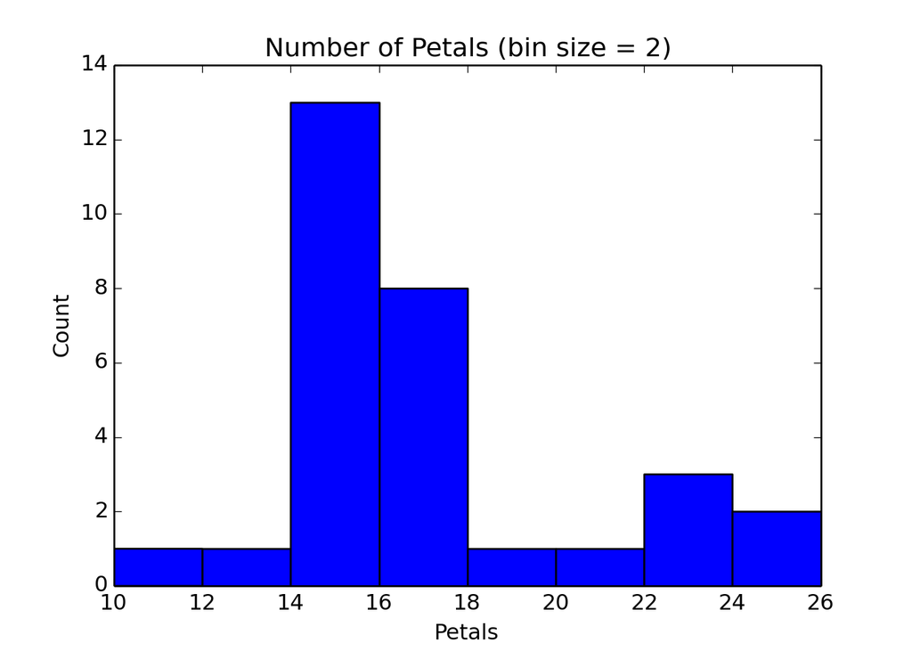

**What number of petals seems most prominent in Kathleen’s garden? What happens if we change the bin size to 5?**  
As we can see from the chart, the most frequent number of petals falls into the interval between 14 and 16 (actually [14,16) ). There are 8 bins of size 2. Mode of the data set equals to 15.

Let’s build the second histogram in R.

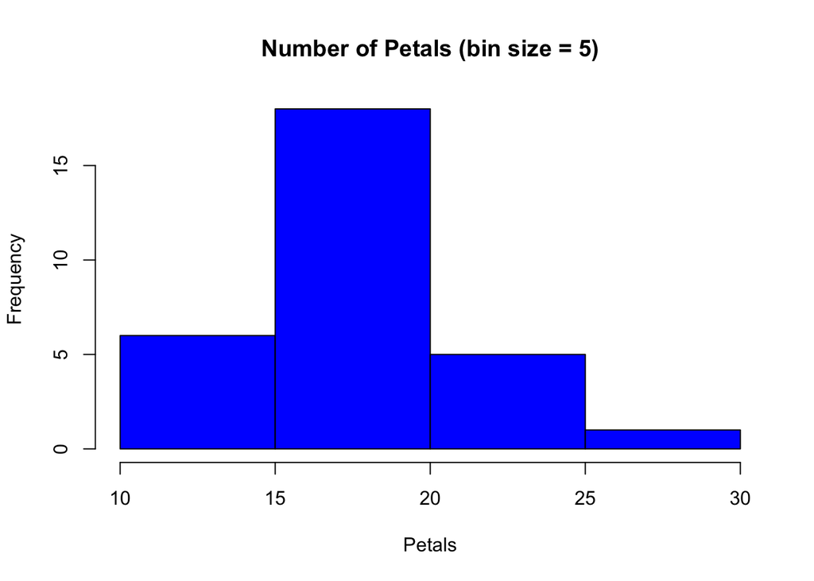

If we change the bin size to 5, the number of bins decreases. I increased the range of data up to a full bin in the end of the range to see all the data on the histogram and added some parameters to ensure that R and Python produce visually the same result. By default Python and R treat the intervals of histograms differently that results in different outcome.

#### Python

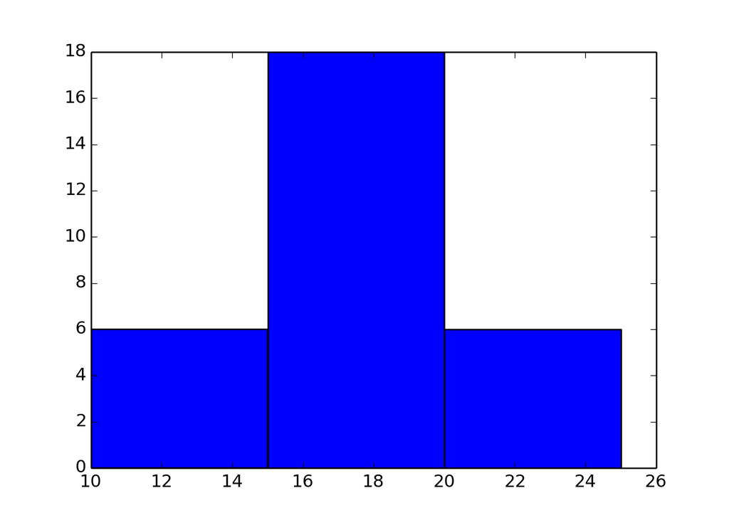

```python
plt.hist(petals, bins=3)
plt.show()
```

With the bin size of 5 Python by default gives us a symmetrial histogram for the petal counts. If *bins* is set by a sequence, all but the last (righthand-most) bin is half-open.

> In other words, if bins is: [1, 2, 3, 4] then the first bin is [1, 2) (including 1, but excluding 2) and the second [2, 3). The last bin, however, is [3, 4], which includes 4". ([source](https://matplotlib.org/api/_as_gen/matplotlib.pyplot.hist.html))

#### R

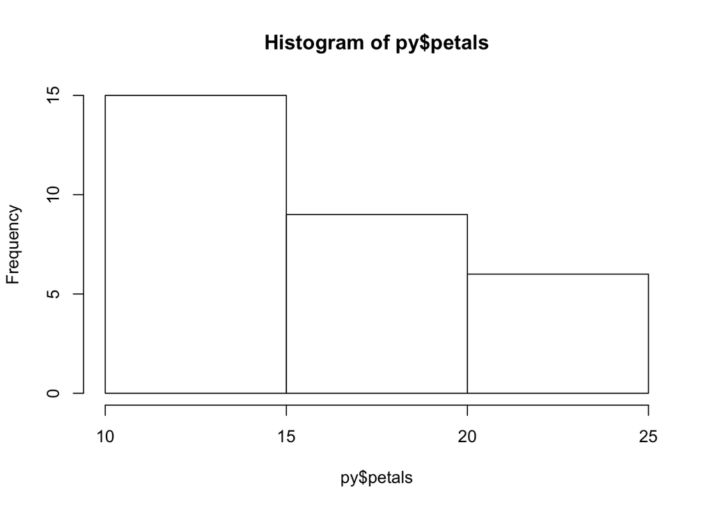

```r
hist(py$petals, breaks = 3)
```

The same parameters in R produced a skewed distribution of the same data, because by default

> the histogram cells are intervals of the form (a, b], i.e., they include their right-hand endpoint, but not their left one, with the exception of the first cell when include.lowest is TRUE. ([source](https://stat.ethz.ch/R-manual/R-devel/library/graphics/html/hist.html))

To change this, the *right* attribute should be set to *FALSE* - then “the intervals are of the form [a, b), and include.lowest means ‘include highest’”.

See the documentation of [Python](https://matplotlib.org/api/_as_gen/matplotlib.pyplot.hist.html) and [R](https://stat.ethz.ch/R-manual/R-devel/library/graphics/html/hist.html) for more information.

### Appendix

The code used in this document

```r
# R setup
library(reticulate)
```

```python
# Python setup
import matplotlib.pyplot as plt
```

```python
petals = [15, 16, 15, 17, 14, 14, 14, 10, 15, 25,
            16, 21, 16, 16, 13, 15, 15, 19, 22, 15,
            17, 22, 15, 22, 14, 15, 16, 15, 24, 16]
print("Kathleen's petal counts:")
print(petals)
```

```python
# Plotting the first histogram in Python
def plot_hist(data, binsize):
  plt.hist(data, bins=range(min(data), max(data) + (binsize - (max(data) - min(data)) % binsize) + binsize, binsize), edgecolor='black')
  plt.title('Number of Petals (bin size = {})'.format(binsize))
  plt.xlabel('Petals')
  plt.ylabel('Count')
  plt.show()
# bin size of 2
plot_hist(petals, 2)
```

```r
# Plotting the second histogram in R
plot_hist <- function(data, binsize) {
  seq_min <- min(data)
  seq_max <- max(data)
  break_seq <- seq(seq_min, seq_max + (binsize - (seq_max - seq_min) %% binsize), by=binsize)
  hist(data, main = paste("Number of Petals (bin size = ", toString(binsize), ")", sep=""), col="blue", xlab="Petals", right=FALSE, breaks = break_seq)
}

# bin size of 5
plot_hist(py$petals, 5)
```

```python
# clearing the chart for another graph to avoid overlapping
plt.close()
```

```python
plt.hist(petals, bins=3)
plt.show()
```

```r
hist(py$petals, breaks = 3)
```